# VS1.3 - Example: An Artificial 1D Dataset

Elvan Ceyhan

2023-12-18

First we load the `pcds` package:

```r
library(pcds)
```

# 1 Illustration of PCDs on an Artificial 1D Dataset

This data set consists of simulated points from two classes, $\mathcal{X}$ and $\mathcal{Y}$, where $\mathcal{X}$ points are uniformly distributed on the interval $[a,b]=[0,10]$, while $\mathcal{Y}$ points are chosen at approximately regular distances for better illustration. Here $n_x$ is the size of class $\mathcal{X}$ points, $n_y$ is the size of class $\mathcal{Y}$ points, and for better illustration of certain structures and graph constructs.

```r
a<-0; b<-10; int<-c(a,b)
#nx is number of X points (target) and ny is number of Y points (nontarget)
nx<-10; ny<-5; #try also nx<-40; ny<-10 or nx<-1000; ny<-10;

xf<-(b-a)*.1
set.seed(11)
Xp<-runif(nx,a-xf,b+xf)
Yp<-runif(ny,-1,1)*(b-a)/(10*ny)+ ((b-a)/(ny-1))*(0:(ny-1)) #try also Yp<-runif(ny,a,b)
```

The scatterplot of $\mathcal{X}$ and $\mathcal{Y}$ points on the real line can be obtained by the below code; $y$-axis is added for better visualization.

```r
XYpts =c(Xp,Yp) #combined Xp and Yp
lab=c(rep(1,nx),rep(2,ny))
lab.fac=as.factor(lab)
plot(XYpts,rep(0,length(XYpts)),col=lab,pch=lab,xlab="x",ylab="",ylim=.005*c(-1,1),
     main="Scatterplot of 1D Points from Two Classes")
```

[output not shown]

The PCDs are constructed with vertices from $\mathcal{X}$ points and Delaunay triangulation of $\mathcal{Y}$ points.

The PCDs in the 1D case are constructed with vertices from $\mathcal{X}$ points and the binary relation that determines the arcs are based on proximity regions which depend on the intervals whose end points are the ordered $\mathcal{Y}$ points (which is the Delaunay tessellation of $\mathcal{Y}$ points in $\mathbb{R}$). More specifically, the proximity regions are defined with respect to the Delaunay cells (i.e., intervals) based on the order statistics of the $\mathcal{Y}$ points and vertex regions in each interval are based on the center $M_c=a+c\,(b-a)$ for the interval $[a,b]$ where $c \in (0,1)$. That is, Delaunay tessellation of $\mathcal{Y}$ points provides an interval partitioning of the range of $\mathcal{Y}$ points based on the order statistics of the $\mathcal{Y}$ points.

The convex hull of $\mathcal{Y}$ points (i.e., the interval $\left[\mathsf{y}_{(1)},\mathsf{y}_{(m)}\right]$) is partitioned by the intervals based on the ordered $\mathcal{Y}$ points (i.e., multiple intervals are the set of these intervals whose union constitutes the range of $\mathcal{Y}$ points).

Below we plot the $\mathcal{X}$ points together with the intervals based on $\mathcal{Y}$ points.

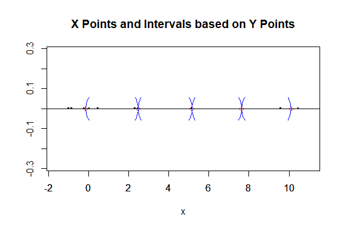

Figure 1.1: The plot of the $X$ points (black circles) in the artificial data set together with the intervals (blue rounded brackets) based on $Y$ points (red circles).

```r
Xlim<-range(Xp)
Ylim<-.005*c(-1,1)
xd<-Xlim[2]-Xlim[1]
plot(Xp,rep(0,nx),xlab="x", ylab=" ",xlim=Xlim+xd*c(-.05,.05), yaxt='n',
     ylim=Ylim,pch=".",cex=3,main="X Points and Intervals based on Y Points")
abline(h=0,lty=2)
#now, we add the intervals based on Y points
par(new=TRUE)
plotIntervals(Xp,Yp,xlab="",ylab="",main="")
```

Or, alternatively, we can use the `plotIntervals` function in `pcds` to obtain the same plot by executing `plotIntervals(Xp,Yp,xlab="",ylab="")` command.

## 1.1 Summary and Visualization with Proportional Edge PCDs

PE proximity regions are defined with respect to the intervals based on $\mathcal{Y}$ points and vertex regions in each interval are based on the centrality parameter `c` in $(0,1)$. For PE-PCDs, the default centrality parameter used to construct the vertex regions is `c=.5` (which gives the center of mass of each interval). The range of $\mathcal{Y}$ is partitioned by the intervals based on the order statistics of (i.e., sorted) $\mathcal{Y}$ points (i.e., multiple intervals are the set of these intervals whose union constitutes the range (or convex hull) of $\mathcal{Y}$ points).

See Ceyhan (2012) for more on PE-PCDs for 1D data.

Number of arcs of the PE-PCD can be computed by the function `num.arcsPE1D` which is an object of class “`NumArcs`” and takes the arguments

- `Xp`, a set or vector of 1D points which constitute the vertices of the PE-PCD,
- `Yp`, a set or vector of 1D points which constitute the end points of the partition intervals,
- `r`, a positive real number which serves as the expansion parameter in PE proximity region; must be $\ge 1$.
- `c`, a positive real number in $(0,1)$ parameterizing the center inside the middle (partition) intervals with the default `c=.5`. For an interval, $(a,b)$, the parameterized center is $M_c=a+c(b-a)$.

Its `call` (with `Narcs` in the below script) just returns the description of the digraph. Its `summary` returns a description of the digraph, number of arcs of the PE-PCD, number of data (`Xp`) points in the range of `Yp` (nontarget) points, number of data points in the partition intervals based on `Yp` points, numbers of arcs in the induced subdigraphs in the partition intervals, lengths of the partition intervals, end points of the vertices of the partition intervals, indices of the partition intervals data points resides. The `plot` function (i.e., `plot.NumArcs`) returns the plot of the partition intervals of `Yp` points, scatter plot of the `Xp` points and the number of arcs of the induced subdigraphs for each partition interval in the centroid of the interval.

This function returns the list of

```
res<-list(desc=desc, #description of the output
        num.arcs=narcs, #number of arcs for the entire PCD
        int.num.arcs=arcs, #vector of number of arcs for the partition intervals
        num.in.range=nx2, #number of Xp points in the range of Yp points
        num.in.ints=ni.vec, #number of Xp points in the partition intervals
        weight.vec=Wvec, #lengths of the middle partition intervals
        partition.intervals=t(part.ints), #matrix of the partition intervals, each column is one interval
        data.int.ind=int.ind, #indices of partition intervals in which data points reside, i.e., column number of part.int for each Xp point
        tess.points=Yp, #tessellation points
        vertices=Xp #vertices of the digraph
```

- `desc`: A description of the PCD and the output
- `num.arcs`: Total number of arcs in all intervals (including the end intervals), i.e., the number of arcs for the entire PE-PCD
- `int.num.arcs`: The `vector` of the number of arcs of the components of the PE-PCD in the partition intervals (including the end intervals) based on `Yp` points,
- `num.in.range`: Number of `Xp` points in the range or convex hull of `Yp` points
- `num.in.ints`: The vector of number of `Xp` points in the partition intervals (including the end intervals) based on `Yp` points
- `weight.vec`: The `vector` of the lengths of the middle partition intervals (i.e., end intervals excluded) based on `Yp` points
- `partition.intervals`: Matrix of the partition intervals, each column is one interval
- `data.int.ind`: A `vector` of indices of partition intervals in which data points reside, i.e., column number of `part.int` is provided for each `Xp` point. Partition intervals are numbered from left to right with 1 being the left end interval.
- `ind.mid`: Indices of data points in the middle interval
- `ind.right.end`: Indices of data points in the right end interval
- `tess.points`: intervalization points (i.e. `Yp` points)
- `vertices`: vertices of the PCD (i.e. `Xp` points)

```r
r<-2 #try also r=1.5
c<-.4  #try also c=.3
```

```r
Narcs = num.arcsPE1D(Xp,Yp,r,c)
summary(Narcs)
```

```
#> Call:
#> num.arcsPE1D(Xp = Xp, Yp = Yp, r = r, c = c)
#>
#> Description of the output:
#> Number of Arcs of the PE-PCD with vertices Xp and Related Quantities for the Induced Subdigraphs for the Points in the Partition Intervals
#>
#> Number of data (Xp) points in the range of Yp (nontarget) points =  6
#> Number of data points in the partition intervals based on Yp points =  3 3 2 0 1 1
#> Number of arcs in the entire digraph =  5
#> Numbers of arcs in the induced subdigraphs in the partition intervals =  4 1 0 0 0 0
#> Lengths of the (middle) partition intervals (used as weights in the arc density of multi-interval case):
#> 2.606255 2.686573 2.477544 2.453178
#>
#> End points of the partition intervals (each column refers to a partition interval):
#>            [,1]       [,2]     [,3]     [,4]      [,5]     [,6]
#> [1,]       -Inf -0.1299548 2.476300 5.162873  7.640417 10.09359
#> [2,] -0.1299548  2.4763001 5.162873 7.640417 10.093595      Inf
#>
#> Indices of the partition intervals data points resides:
#> 2 1 3 1 1 6 2 3 5 2
#>
```

```r
#plot(Narcs)
```

The incidence matrix of the PE-PCD can be found by `inci.matPE1D` function by running `inci.matPE1D(Xp,Yp,r,c)`. As in the 2D case, given the incidence matrix, we can find the approximate or the exact domination number of the PE-PCD, using the functions `dom.num.greedy` and `dom.num.exact`.

Plot of the arcs of the digraph PE-PCD are provided by the function `plotPEarcs1D`, which take the arguments

- `Xp,Yp,r,c` are same as in the function `num.arcsPE1D`,
- `Jit`, a positive real number that determines the amount of jitter along the $y$-axis, default=`0.1` and `Xp` points are jittered according to $U(-Jit,Jit)$ distribution along the $y$-axis where `Jit` equals to the range of the union of `Xp` and `Yp` points multiplied by `Jit`).
- `main` an overall title for the plot (default=`NULL`),
- `xlab,ylab` titles for the $x$ and $y$ axes, respectively (default=`NULL` for both),
- `xlim,ylim`, two numeric vectors of length 2, giving the $x$- and $y$-coordinate ranges (default=`NULL` for both),
- `centers`, a logical argument, if `TRUE`, the plot includes the centers of the intervals as vertical lines in the plot, else centers of the intervals are not plotted, and
- `...`, additional `plot` parameters.

We plot the arcs together with the centers, with `centers=TRUE` option in the plot function. Arcs are jittered along the $y$-axis to avoid clutter on the real line and thus provide better visualization.

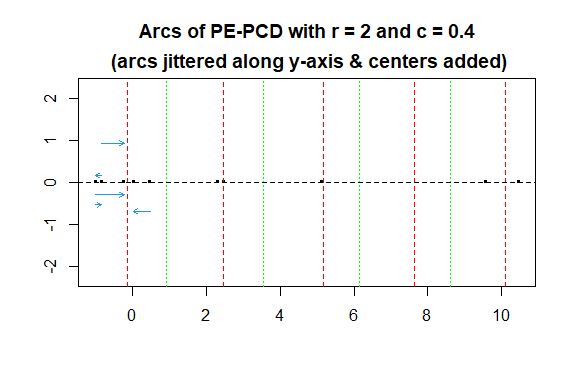

Figure 1.2: The arcs of the PE-PCD for the 1D artificial data set with centrality parameter $c=.4$, the end points of the $Y$ intervals (red) and the centers (green) are plotted with vertical dashed lines.

```r
jit<-.1
set.seed(1)
plotPEarcs1D(Xp,Yp,r,c,jit,xlab="",ylab="",centers=TRUE)
```

Plots of the PE proximity regions (i.e. proximity intervals) are provided with the function `plotPEregs1D`, which has the same arguments as the function `plotPEarcs1D`. We plot the proximity regions together with the centers with `centers=TRUE` option:

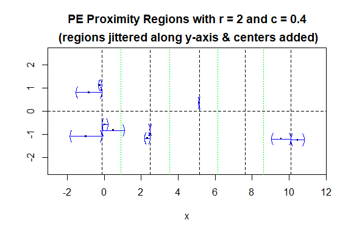

Figure 1.3: The PE proximity regions (blue) for the 1D artificial data set, the end points of the $Y$ intervals (black) and the centers (green) are plotted with vertical dashed lines.

```r
set.seed(12)
plotPEregs1D(Xp,Yp,r,c,xlab="x",ylab="",centers = TRUE)
```

The function `arcsPE1D` is an object of class “`PCDs`” and has the same arguments as in `num.arcsPE1D`. Its `call` (with `Arcs` in the below script) just provides the description of the digraph, and `summary` provides a description of the digraph, the names of the data points constituting the vertices of the digraph and also the interval points, selected tail (or source) points of the arcs in the digraph (first 6 or fewer are printed), selected head (or end) points of the arcs in the digraph (first 6 or fewer are printed), the parameters of the digraph (here centrality parameter and the expansion parameter), and various quantities of the digraph (namely, the number of vertices, number of partition points, number of triangles, number of arcs, and arc density. The `plot` function (i.e., `plot.PCDs`) provides the plot of the arcs in the digraph together with the intervals based on the ordered $\mathcal{Y}$ points.

For this function, PE proximity regions are constructed for data points inside or outside the intervals based on `Yp` points with expansion parameter $r \ge 1$ and centrality parameter $c \in (0,1)$. That is, for this function, arcs may exist for points in the middle and end intervals. Arcs are jittered along the $y$-axis in the plot for better visualization. The `plot` function returns the same plot as in `plotPEarcs1D`, hence we comment it out below.

```r
Arcs<-arcsPE1D(Xp,Yp,r,c)
Arcs
```

```
#> Call:
#> arcsPE1D(Xp = Xp, Yp = Yp, r = r, c = c)
#>
#> Type:
#> [1] "Proportional Edge Proximity Catch Digraph (PE-PCD) for 1D Points with Expansion Parameter r = 2 and Centrality Parameter c = 0.4"
```

```r
summary(Arcs)
```

```
#> Call:
#> arcsPE1D(Xp = Xp, Yp = Yp, r = r, c = c)
#>
#> Type of the digraph:
#> [1] "Proportional Edge Proximity Catch Digraph (PE-PCD) for 1D Points with Expansion Parameter r = 2 and Centrality Parameter c = 0.4"
#>
#>  Vertices of the digraph =  Xp
#>  Partition points of the region =  Yp
#>
#>  Selected tail (or source) points of the arcs in the digraph
#>       (first 6 or fewer are printed)
#> [1] 3.907723 4.479377 5.617220 8.459662 8.459662 9.596209
#>
#>  Selected head (or end) points of the arcs in the digraph
#>       (first 6 or fewer are printed)
#> [1] 4.479377 3.907723 5.337266 9.596209 9.709029 9.709029
#>
#> Parameters of the digraph
#> centrality parameter  expansion parameter
#>                  0.4                  2.0
#>
#> Various quantities of the digraph
#>         number of vertices number of partition points
#>                10.00000000                 5.00000000
#>        number of intervals             number of arcs
#>                 6.00000000                 6.00000000
#>                arc density
#>                 0.06666667
```

```r
set.seed(1)
plot(Arcs)
```

### 1.1.1 Testing Interaction and Uniformity with the PE-PCDs

We can test the interaction between two classes/species or uniformity of points from one class in the 1D setting based on *arc density* or *domination number* of PE-PCDs.

**The Use of Arc Density of PE-PCDs for Testing 1D Interaction**

We can test the 1D interaction of segregation/association or uniformity based on arc density of PE-PCD using the function `PEarc.dens.test1D` which takes the arguments `Xp,Yp,r,c,support.int,end.int.cor,alternative,conf.level` where

- `r,alternative,conf.level` are as in `PEarc.dens.test`,
- `Xp`, a set of 1D points which constitute the vertices of the PE-PCD,
- `Yp`, a set of 1D points which constitute the end points of the partition intervals,
- `support.int`, the support interval $(a,b)$ with $a<b$. Uniformity of `Xp` points in this interval is tested, default is `NULL`.
- `c`, a positive real number which serves as the centrality parameter in PE proximity region; must be in $(0,1)$ (default `c=.5`).
- `end.int.cor`, a logical argument for end interval correction, default is `FALSE`, recommended when both `Xp` and `Yp` have the same interval support.

This function is an object of class “`htest`” (i.e., *hypothesis test*) and performs a hypothesis test of complete spatial randomness (CSR) or uniformity of `Xp` points in the range of `Yp` points against the alternatives of segregation (where `Xp` points cluster away from `Yp` points) and association (where `Xp` points cluster around `Yp` points) based on the normal approximation of the arc density of the PE-PCD for uniform 1D data utilizing the asymptotic normality of the $U$-statistics. For testing of uniformity of $\mathcal{X}$ points in a bounded interval support, $\mathcal{Y}$ points are artificially inserted randomly or at regular distances in the support.

The function is based on similar assumptions and returns the similar type of output as in `PEarc.dens.test`, see Section “VS1_1_2DArtiData” and also Ceyhan (2012) for more on the uniformity test based on the arc density of PE-PCDs for 1D data.

```r
PEarc.dens.test1D(Xp,Yp,r,c) # try also PEarc.dens.test1D(Xp,Yp,r,c,alt="l")
```

```
#>
#>  Large Sample z-Test Based on Arc Density of PE-PCD for Testing
#>  Uniformity of 1D Data ---
#>  without End Interval Correction
#>
#> data:  Xp
#> standardized arc density (i.e., Z) = -0.77073, p-value = 0.4409
#> alternative hypothesis: true (expected) arc density is not equal to 0.1279913
#> 95 percent confidence interval:
#>  0.05557408 0.15952931
#> sample estimates:
#> arc density
#>   0.1075517
```

**The Use of Domination Number of PE-PCDs for Testing 1D Interaction**

We first provide two functions to compute the domination number of PE-PCDs: `PEdom.num1D` and `PEdom.num1Dnondeg`.

The function `PEdom.num1D` takes the same arguments as `num.arcsPE1D` and returns a `list` with four elements as output:

- `dom.num`, the overall domination number of PE-PCD with vertex set `Xp` and expansion parameter $r \ge 1$ and centrality parameter $c \in (0,1)$,
- `mds`, a minimum dominating set of the PE-PCD,
- `ind.mds`, the vector of data indices of the minimum dominating set of the PE-PCD whose vertices are `Xp` points,
- `int.dom.nums`, the vector of domination numbers of the PE-PCD components for the partition intervals.

This function takes any center in the interior of the intervals as its argument. The vertex regions in each interval are based on the center $M_c=(a+c(b-a)$ for the interval $[a,b]$ with $c \in (0,1)$ (default for $c=.5$ which gives the center of mass of the interval).

On the other hand, `PEdom.num1Dnondeg` takes only the arguments `Xp,Yp,r` and returns the same output as in `PEdom.num1D` function, but uses one of the non-degeneracy centrality values in the multiple interval case (hence `c` is not an argument for this function). That is, `c` is one of the two values $\{(r-1)/r,1/r\}$ that renders the asymptotic distribution of domination number non-degenerate for a given value of $r \in (1,2]$ and `M` is center of mass (i.e., $c=.5$) for $r=2$.

These two functions are different from the function `dom.num.greedy` since they give an exact minimum dominating set and the exact domination number and from `dom.num.exact`, since they give a minimum dominating set and the domination number in polynomial time (in the number of vertices of the digraph, i.e., number of `Xp` points).

```r
PEdom.num1D(Xp,Yp,r,c)
```

```
#> $dom.num
#> [1] 6
#>
#> $mds
#> [1] -0.453322  2.450930  3.907723  5.617220  8.459662 10.285607
#>
#> $ind.mds
#> [1] 6 1 3 9 2 5
#>
#> $int.dom.nums
#> [1] 1 1 1 1 1 0 0 1
```

```r
PEdom.num1Dnondeg(Xp,Yp,r)
```

```
#> $dom.num
#> [1] 7
#>
#> $mds
#> [1] -0.453322  2.450930  3.907723  5.617220  8.459662  9.596209 10.285607
#>
#> $ind.mds
#> [1] 6 1 3 9 2 4 5
#>
#> $int.dom.nums
#> [1] 1 1 1 1 2 0 0 1
```

We can test the interaction pattern of segregation/association or uniformity based on domination of PE-PCD using the function `PEdom.num.binom.test1D` or `PEdom.num.binom.test1Dint`, each of which is an object of class “`htest`” and performs the same hypothesis test as in `PEarc.dens.test1D`. This function takes the same arguments as in `PEarc.dens.test1D` and returns the test statistic, $p$-value for the corresponding `alternative`, the confidence interval, estimate and null value for the parameter of interest (which is $P(\mbox{domination number}\le 1)$), and method and name of the data set used.

Under the null hypothesis of uniformity of `Xp` points in the range of `Yp` points, probability of success (i.e., $P(\mbox{domination number}\le 1)$) equals to its expected value under the uniform distribution) and `alternative` could be two-sided, or right-sided (i.e., data is accumulated around the `Yp` points, or association) or left-sided (i.e., data is accumulated around the centers of the triangles, or segregation).

Here, the PE proximity region is constructed with the centrality parameter $c \in (0,1)$ with an expansion parameter $r \ge 1$ that yields non-degenerate asymptotic distribution of the domination number. That is, for the centrality parameter `c` and for a given $c \in (0,1)$, the expansion parameter $r$ is taken to be $1/\max(c,1-c)$ which yields non-degenerate asymptotic distribution of the domination number.

The test statistic in `PEdom.num.binom.test1D` is based on the binomial distribution, when success is defined as domination number being less than or equal to 1 in the one interval case (i.e., number of successes is equal to domination number $\le 1$ in the partition intervals). That is, the test statistic is based on the domination number for `Xp` points inside the range of `Yp` points for the PE-PCD and default end interval correction, `end.int.cor`, is `FALSE`. For this approximation to work, `Xp` must be at least 5 times more than `Yp` points (or `Xp` must be at least 5 or more per partition interval). Here, the probability of success is the exact probability of success for the binomial distribution. See also Ceyhan (2020) for more on the uniformity test based on the domination number of PE-PCDs for 1D data. For testing uniformity of $\mathcal{X}$ points in $(0,10)$, one can run `PEdom.num.binom.test1Dint(Xp,int,c)` (here the default options are used for the other arguments).

```r
PEdom.num.binom.test1D(Xp,Yp,c) #try also PEdom.num.binom.test1D(Xp,Yp,c,alt="l")
```

```
#>
#>  Large Sample Binomial Test based on the Domination Number of PE-PCD for
#>  Testing Uniformity of 1D Data ---
#>  without End Interval Correction
#>
#> data:  Xp
#> adjusted domination number = 0, p-value = 0.3042
#> alternative hypothesis: true Pr(Domination Number=2) is not equal to 0.375
#> 95 percent confidence interval:
#>  0.0000000 0.6023646
#> sample estimates:
#>          domination number   || Pr(domination number = 2)
#>                            6                            0
```

In all the test functions (based on arc density and domination number) above, the option `end.int.cor` is for end interval correction (default is “no end interval correction”, i.e., `end.int.cor = FALSE`) which is recommended when both `Xp` and `Yp` have the same interval support. When the symmetric difference of the supports is non-negligible, the tests are modified to account for the $\mathcal{X}$ points outside the range of $\mathcal{Y}$ points. For example, `PEarc.dens.test1D(Xp,Yp,r,c,end.int.cor = TRUE)` would yield the end interval corrected version of the arc-based test of 1D interaction. Furthermore, we only provide the two-sided tests above, although both one-sided versions are also available.

## 1.2 Summary and Visualization with Central Similarity PCDs

CS proximity regions are defined similar to the PE proximity regions in Section 1.1. Note also that for CS-PCDs in two dimensions, we use the edge regions to construct the proximity region, however, in the one dimensional setting, vertex and edge regions coincide, so we refer these regions as “vertex” regions for convenience. The default centrality parameter used to construct the vertex regions is again `c=0.5` which yields the center of mass of each interval.

The functions for CS-PCD have similar arguments as the PE-PCD functions with the expansion parameter `r` replaced with `t` (which must be positive). Number of arcs of the CS-PCD can be computed by the function `num.arcsCS1D`, which is an object of class “`NumArcs`” and takes same arguments (except expansion parameter `t`) and returns similar output items as in `num.arcsPE1D`.

```r
tau<-2; c<-.4
```

```r
Narcs = num.arcsCS1D(Xp,Yp,tau,c)
summary(Narcs)
```

```
#> Call:
#> num.arcsCS1D(Xp = Xp, Yp = Yp, t = tau, c = c)
#>
#> Description of the output:
#> Number of Arcs of the CS-PCD with vertices Xp and Related Quantities for the Induced Subdigraphs for the Points in the Partition Intervals
#>
#> Number of data (Xp) points in the range of Yp (nontarget) points =  6
#> Number of data points in the partition intervals based on Yp points =  3 3 2 0 1 1
#> Number of arcs in the entire digraph =  6
#> Numbers of arcs in the induced subdigraphs in the partition intervals =  4 2 0 0 0 0
#> Lengths of the (middle) partition intervals (used as weights in the arc density of multi-interval case):
#> 2.606255 2.686573 2.477544 2.453178
#>
#> End points of the partition intervals (each column refers to a partition interval):
#>            [,1]       [,2]     [,3]     [,4]      [,5]     [,6]
#> [1,]       -Inf -0.1299548 2.476300 5.162873  7.640417 10.09359
#> [2,] -0.1299548  2.4763001 5.162873 7.640417 10.093595      Inf
#>
#> Indices of the partition intervals data points resides:
#> 2 1 3 1 1 6 2 3 5 2
```

```r
#plot(Narcs)
```

The incidence matrix of the CS-PCD can be found by `inci.matCS1D` by running `inci.matCS1D(Xp,Yp,t=1.5,c)` command. With the incidence matrix, approximate and exact domination numbers can be found by the functions `dom.num.greedy` and `dom.num.exact`, respectively.

Plot of the arcs in the digraph CS-PCD is provided by the function `plotCSarcs1D`, which take same arguments as the function `plotPEarcs1D`. We plot the arcs together with the centers, with `centers=TRUE` option in the plot function. Arcs are jittered along the $y$-axis to avoid clutter on the real line (i.e., for better visualization).

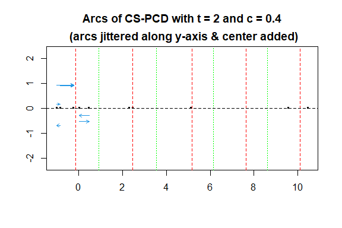

Figure 1.4: The arcs of the CS-PCD for the 1D artificial data set with centrality parameter $c=.4$, the end points of the $Y$ intervals (red) and the centers (green) are plotted with vertical dashed lines.

```r
set.seed(1)
plotCSarcs1D(Xp,Yp,tau,c,jit,xlab="",ylab="",centers=TRUE)
```

Plot of the CS proximity regions (or intervals) is provided with the function `plotCSregs1D`, which take same arguments as the function `plotPEregs1D`. We plot the proximity regions together with the centers with `centers=TRUE` option:

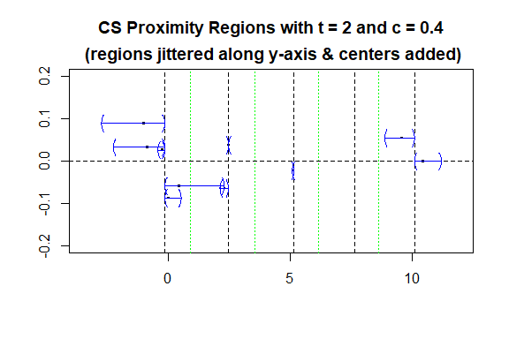

Figure 1.5: The CS proximity regions (blue) for the 1D artificial data set, the end points of the $Y$ intervals (black) and the centers (green) are plotted with vertical dashed lines.

```r
plotCSregs1D(Xp,Yp,tau,c,xlab="",ylab="",centers = TRUE)
```

The function `arcsCS1D` is an object of class “`PCDs`” and has the same arguments as in `num.arcsCS1D`. Its `call`, `summary`, and `plot` are as in `arcsPE1D`. For this function, CS proximity regions are constructed for data points inside or outside the intervals based on `Yp` points with expansion parameter $t > 0$ and centrality parameter $c \in (0,1)$. That is, for this function, arcs may exist for points in the middle or end intervals. Arcs are jittered along the $y$-axis in the plot for better visualization. The `plot` function returns the same plot as in `plotCSarcs1D`, hence we comment it out below.

```r
Arcs<-arcsCS1D(Xp,Yp,tau,c)
Arcs
```

```
#> Call:
#> arcsCS1D(Xp = Xp, Yp = Yp, t = tau, c = c)
#>
#> Type:
#> [1] "Central Similarity Proximity Catch Digraph (CS-PCD) for 1D Points with Expansion Parameter t = 2 and Centrality Parameter c = 0.4"
```

```r
summary(Arcs)
```

```
#> Call:
#> arcsCS1D(Xp = Xp, Yp = Yp, t = tau, c = c)
#>
#> Type of the digraph:
#> [1] "Central Similarity Proximity Catch Digraph (CS-PCD) for 1D Points with Expansion Parameter t = 2 and Centrality Parameter c = 0.4"
#>
#>  Vertices of the digraph =  Xp
#>  Partition points of the region =  Yp
#>
#>  Selected tail (or source) points of the arcs in the digraph
#>       (first 6 or fewer are printed)
#> [1] 3.907723 4.479377 5.337266 5.617220 8.459662 8.459662
#>
#>  Selected head (or end) points of the arcs in the digraph
#>       (first 6 or fewer are printed)
#> [1] 4.479377 3.907723 5.617220 5.337266 9.596209 9.709029
#>
#> Parameters of the digraph
#> centrality parameter  expansion parameter
#>                  0.4                  2.0
#> Various quantities of the digraph
#>         number of vertices number of partition points
#>                10.00000000                 5.00000000
#>        number of intervals             number of arcs
#>                 6.00000000                 8.00000000
#>                arc density
#>                 0.08888889
```

```r
plot(Arcs)
```

### 1.2.1 Testing 1D Interaction or Uniformity with the CS-PCDs

We can test the 1D interaction between two classes/species or uniformity of points from one class in the 1D setting based on *arc density* of CS-PCDs. The distribution of the domination number of CS-PCDs is still a topic of ongoing work.

**The Use of Arc Density of CS-PCDs for Testing 1D Interaction or Uniformity**

We can test the 1D interaction of segregation/association or uniformity based on arc density of CS-PCD using the function `CSarc.dens.test1D`. This function is an object of class “`htest`” (i.e., *hypothesis test*), takes the same arguments as the function `PEarc.dens.testS1D` with expansion parameter `r` replaced with `t`, performs the same type of test with the same null and alternative hypotheses, and returns similar output as the `PEarc.dens.test1D` function. See Section 1.1, and also Ceyhan (2016) for more details.

```r
CSarc.dens.test1D(Xp,Yp,tau,c) #try also CSarc.dens.test1D(Xp,Yp,tau,c,alt="l")
```

```
#>
#>  Large Sample z-Test Based on Arc Density of CS-PCD for Testing
#>  Uniformity of 1D Data ---
#>  without End Interval Correction
#>
#> data:  Xp
#> standardized arc density (i.e., Z) = -0.75628, p-value = 0.4495
#> alternative hypothesis: true (expected) arc density is not equal to 0.1658151
#> 95 percent confidence interval:
#>  0.08507259 0.20159565
#> sample estimates:
#> arc density
#>   0.1433341
```

As in the tests based on PE-PCD, it is possible to account for $\mathcal{X}$ points outside the range of $\mathcal{Y}$ points, with the option `end.int.cor = TRUE`. For example, `CSarc.dens.test1D(Xp,Yp,tau,c,end.int.cor = TRUE)` would yield the end interval corrected version of the arc-based test of 1D interaction. Furthermore, we only provide the two-sided test above, although both one-sided versions are also available.

**References**

Ceyhan, E. 2012. “The Distribution of the Relative Arc Density of a Family of Interval Catch Digraph Based on Uniform Data.” *Metrika* 75(6): 761–93.

———. 2016. “Density of a Random Interval Catch Digraph Family and Its Use for Testing Uniformity.” *REVSTAT* 14(4): 349–94.

———. 2020. “Domination Number of an Interval Catch Digraph Family and Its Use for Testing Uniformity.” *Statistics* 54(2): 310–39.